# Report

Caspar van Lissa & Eli Clapper

13 May, 2022

# Intro

Report on the results

# Results

For each algorithm, a confusion matrix was obtained by tabulating inferential decisions made using that algorithm against the population status of the hypothesis (true or false). For all BFs, the informative hypothesis was accepted if BF > 3. For the IPD and RMA meta-analysis, the null-hypothesis was rejected if the confidence interval for the overall effect size excluded the hypothesized value. Finally, for the vote count (VC) algorithm, the null was rejected if all individual group hypotheses were rejected. Table @ref(tab:tabconf) shows the resulting confusion matrix metrics. The only algorithm that shows relatively high values for both sensitivity and specificity is the product Bayes factor (PBF). This is also reflected in the high accuracy, which represents the total proportion of correct (true positive/true negative) decisions.

Marginal confusion matrix metrics.

| Metric | PBF | IPD | RMA | VC |
| --- | --- | --- | --- | --- |
| sensitivity | 0.76 | 0.35 | 0.32 | 0.05 |
| specificity | 0.76 | 0.99 | 0.99 | 1.00 |
| accuracy | 0.76 | 0.67 | 0.66 | 0.52 |

These results indicate that all algorithms except PBF had low sensitivity to detect a true effect. In contrast, specificity was very high for all algorithms except PBF. This suggests that the other algorithms classified most conditions as negatives (no effect found), regardless of the existence of a population effect. The PBF trades a loss of specificity for increased sensitivity, and average levels of both were approximately equal. As the PBF vastly outperformed other BFs, these were omitted from further analysis.

## Effect of simulation conditions

We examined the effect of simulation conditions on overall accuracy.

Partial eta squared of the effect of each design factor on accuracy for each algorithm and for the difference between PBF and all other algorithms (e.g., vs RMA).

| condition | IPD | RMA | VC | PBF | vs IPD | vs RMA | vs VC |
| --- | --- | --- | --- | --- | --- | --- | --- |
| k | 0.35 | 0.40 | 0.13 | 0.32 | 0.01 | 0.02 | 0.23 |
| n | 0.60 | 0.58 | 0.29 | 0.62 | 0.01 | 0.00 | 0.19 |
| reliability | 0.62 | 0.61 | 0.23 | 0.04 | 0.27 | 0.25 | 0.01 |

PBF performance was most impacted by sample size $n$, followed by the number of groups $k$, and residual heterogeneity.

### Effect of sample size

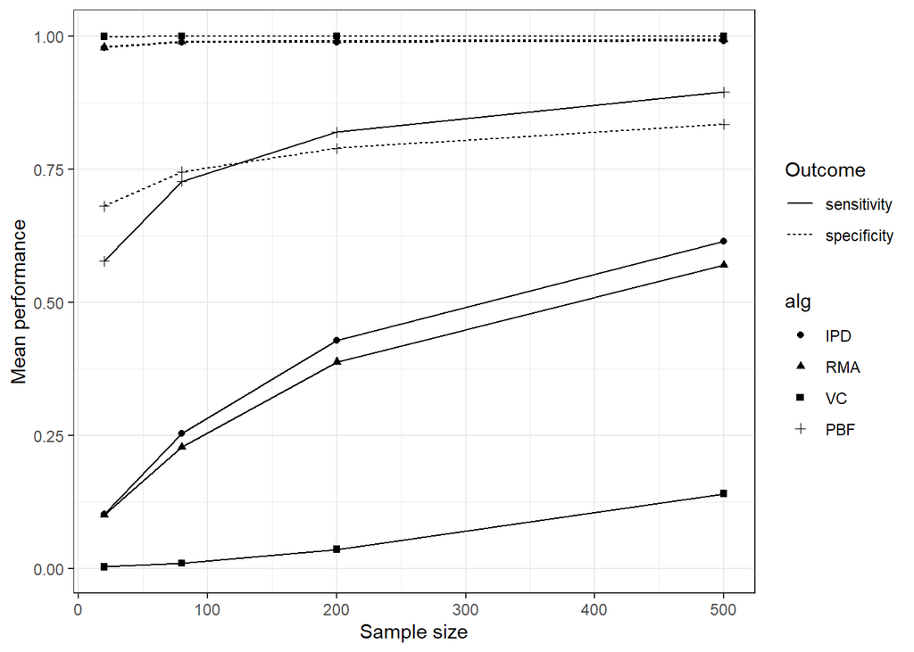

Mean performance by sample size

```r
res <- readRDS("../confusion_by_cond.RData")
res <- res[res$alg %in% c("IPD", "RMA", "VC", "PBF"), ]

df_plot <- melt(res, measure.vars = c("sensitivity", "specificity"),
             variable.name = "Outcome", value.name = "val")
df_plot <- df_plot[ ,list(mean=mean(val)), by=c("n", "Outcome", "alg")]
ggplot(df_plot, aes(x = n, y = mean, group = interaction(Outcome, alg), shape = alg, linetype = Outcome)) +
  geom_point() +
  geom_line() +
  theme_bw() +
  labs(y = "Mean performance", x = "Sample size")
```

### Effect of number of groups

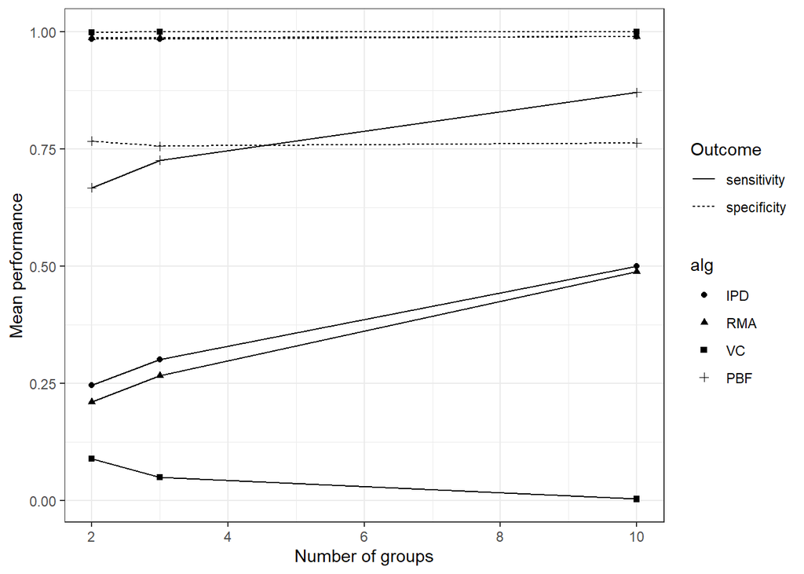

Mean performance by number of groups

```r
df_plot <- melt(res, measure.vars = c("sensitivity", "specificity"),
             variable.name = "Outcome", value.name = "val")
df_plot <- df_plot[ ,list(mean=mean(val)), by=c("k", "Outcome", "alg")]
ggplot(df_plot, aes(x = k, y = mean, group = interaction(Outcome, alg), shape = alg, linetype = Outcome)) +
  geom_point() +
  geom_line() +
  theme_bw() +
  labs(y = "Mean performance", x = "Number of groups")
```

### Effect of residual heterogeneity

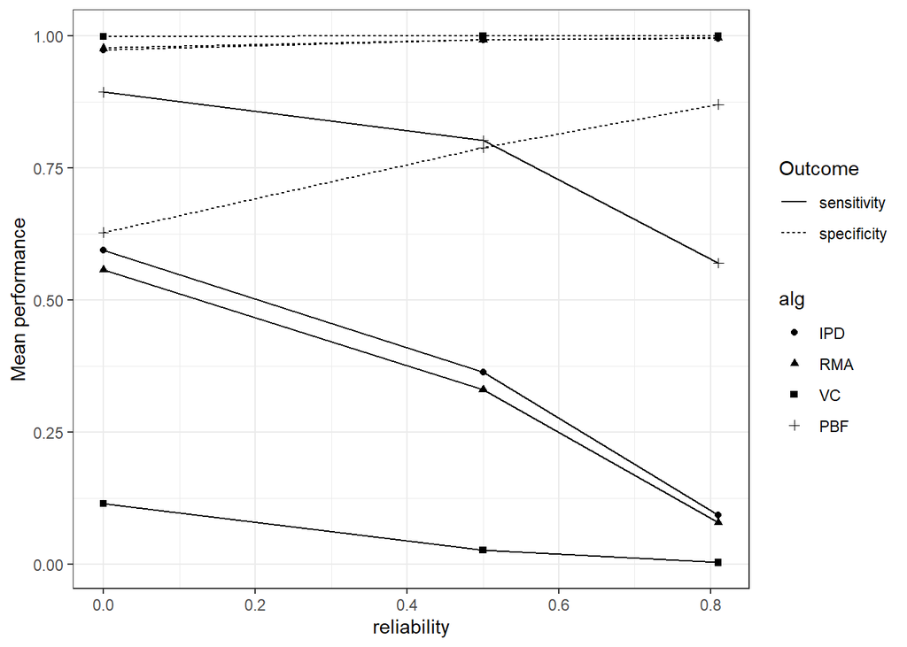

Mean performance by errorsd

```r
df_plot <- melt(res, measure.vars = c("sensitivity", "specificity"),
             variable.name = "Outcome", value.name = "val")
df_plot <- df_plot[ ,list(mean=mean(val)), by=c("reliability", "Outcome", "alg")]
ggplot(df_plot, aes(x = reliability, y = mean, group = interaction(Outcome, alg), shape = alg, linetype = Outcome)) +
  geom_point() +
  geom_line() +
  theme_bw() +
  labs(y = "Mean performance")
```

The figure indicates that for PBF, at higher levels of residual heterogeneity, lower sensitivity is exchanged for greater specificity. The other algorithms do not show this pattern, as their specificity is at a ceiling. Their sensitivity decreases with residual heterogeneity, and therefore, so does their overall performance. This difference in pattern of effects explains why residual heterogeneity has a moderate effect on the difference between algorithms (see Table @ref(tab:tabeffect)). Note that, in contrast to other algorithms, the performance of PBF is less susceptible to residual heterogeneity.

# Discussion

Within the scope of this simulation, PBF had relatively better inferential properties than the other algorithms under consideration. Although other algorithms had superior specificity, PBF had the highest levels of sensitivity. Thus, PBF balanced the ability to accept an informative hypothesis in the presence of a true population effect with the ability to reject the hypothesis when there was no effect.

An important caveat is that none of the algorithms met conventional criteria for power (80%) and type I error (5%). Overall, PBF had the best performance, with power of 76% and type I error of 24%. Thus, if researchers intend to synthesize evidence for an informative hypothesis across heterogeneous studies, PBF may be the most suitable method - but its limitations should be acknowledged in applied research.

The overall performance of PBF increased most with increasing sample size. With an increasing number of groups, slightly decreasing specificity was traded off for increasing sensitivity. With increasing residual heterogeneity, increasing specificity was traded off for decreasing sensitivity.